# M280 Assignment2

### 7.5.1.1

1. Use what you’ve learned to improve the visualisation of the departure times of cancelled vs. non-cancelled flights.

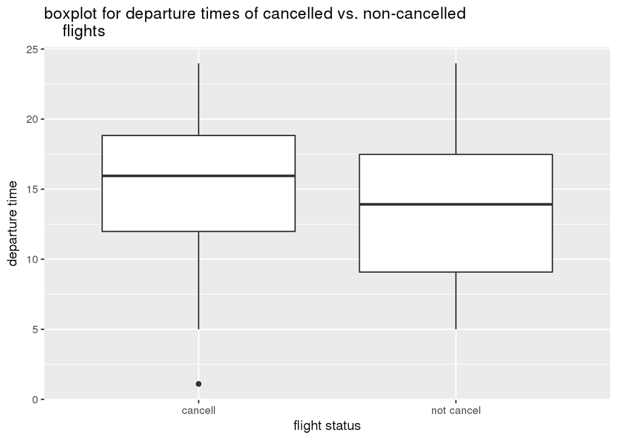

```r
flights %>% mutate(cancell = ifelse(is.na(dep_time) |is.na(arr_time), "cancell",
                                    "not cancel"),
                   sched_hour = sched_dep_time %/% 100,
                   sched_min = sched_dep_time %% 100,
                   sched_dep_time = sched_hour + sched_min / 60) %>%
  ggplot() +
  geom_boxplot(aes(x = cancell, y = sched_dep_time)) +
  labs(
    title = "boxplot for departure times of cancelled vs. non-cancelled
    flights",
    x = "flight status",
    y = "departure time"
  )
```

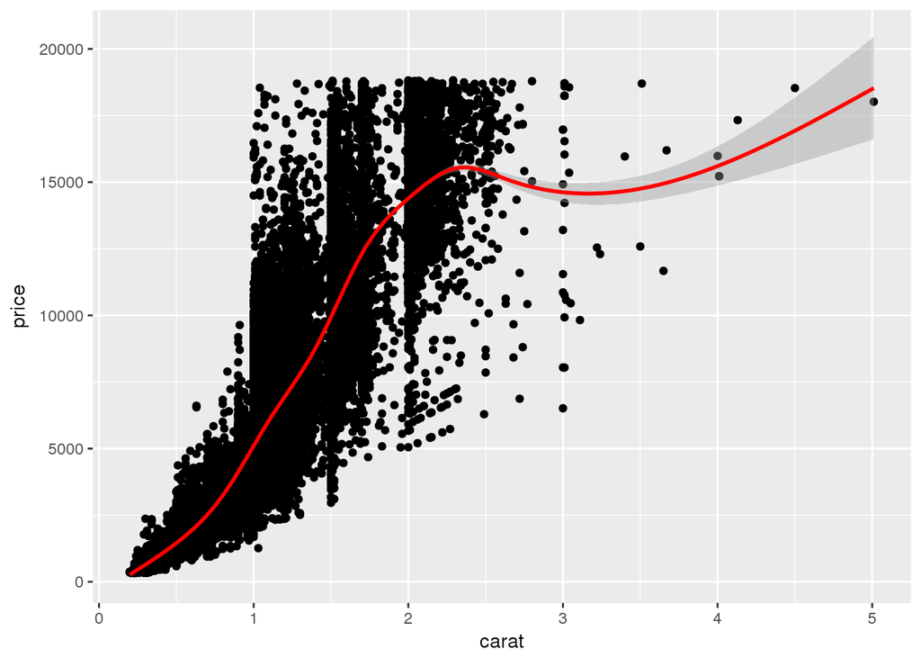

```r
# show scatterplot of price vs carat
ggplot(diamonds) +
  geom_point(aes(x = carat, y = price), color = "black") +
  geom_smooth(aes(x = carat, y = price), color = "red")
```

```r
  labs(
    title = "scatterplot of price vs carat"
  )
```

```
## $title
## [1] "scatterplot of price vs carat"
##
## attr(,"class")
## [1] "labels"
```

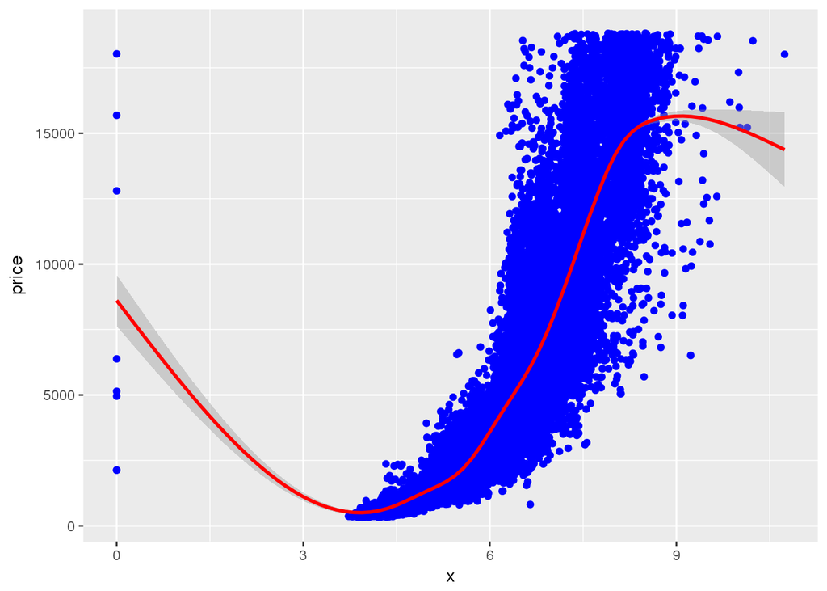

```r
# show scatterplot of price vs x
ggplot(diamonds) +
  geom_point(aes(x = x, y = price), color = "blue") +
  geom_smooth(aes(x = x, y = price), color = "red")
```

```r
  labs(
    title = "scatterplot of price vs x"
  )
```

```
## $title
## [1] "scatterplot of price vs x"
##
## attr(,"class")
## [1] "labels"
```

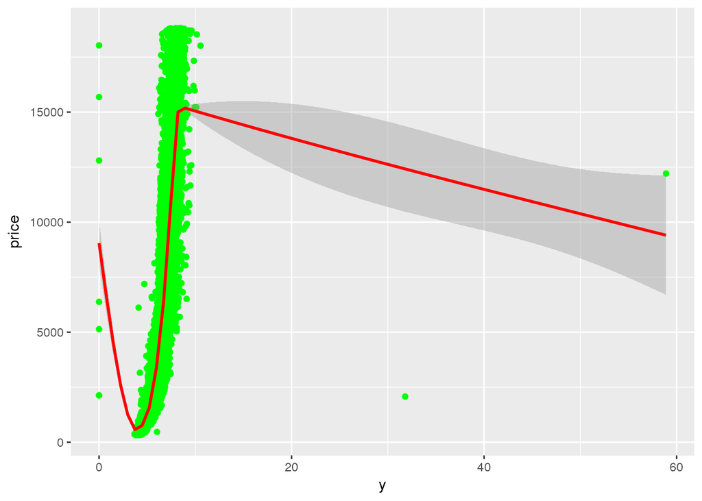

```r
# show scatterplot of price vs y
ggplot(diamonds) +
  geom_point(aes(x = y, y = price), color = "green") +
  geom_smooth(aes(x = y, y = price), color = "red")
```

```r
  labs(
    title = "scatterplot of price vs y"
  )
```

```
## $title
## [1] "scatterplot of price vs y"
##
## attr(,"class")
## [1] "labels"
```

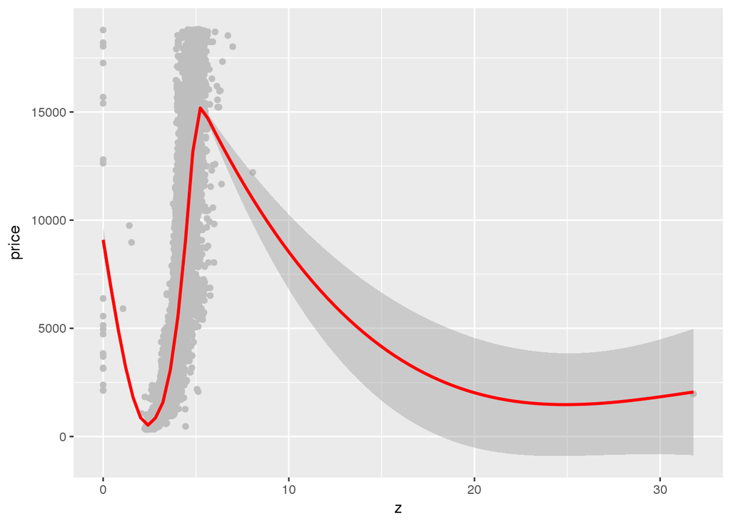

```r
# show scatterplot of price vs z
ggplot(diamonds) +
  geom_point(aes(x = z, y = price), color = "grey") +
  geom_smooth(aes(x = z, y = price), color = "red")
```

```r
  labs(
    title = "scatterplot of price vs z"
  )
```

```
## $title
## [1] "scatterplot of price vs z"
##
## attr(,"class")
## [1] "labels"
```

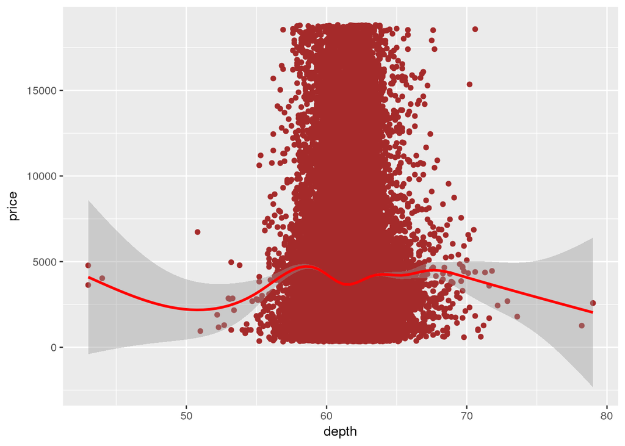

```r
# show scatterplot of price vs depth
ggplot(diamonds) +
  geom_point(aes(x = depth, y = price), color = "brown") +
  geom_smooth(aes(x = depth, y = price), color = "red")
```

```r
  labs(
    title = "scatterplot of price vs depth"
  )
```

```
## $title
## [1] "scatterplot of price vs depth"
##
## attr(,"class")
## [1] "labels"
```

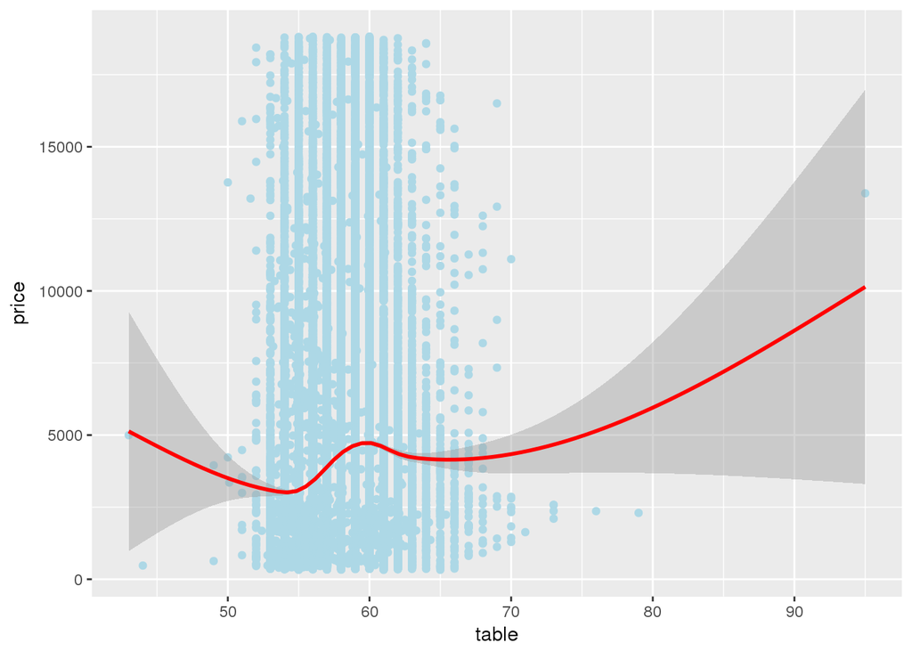

```r
# show scatterplot of price vs table
ggplot(diamonds) +
  geom_point(aes(x = table, y = price), color = "lightblue") +
  geom_smooth(aes(x = table, y = price), color = "red")
```

```r
  labs(
    title = "scatterplot of price vs carat"
  )
```

```
## $title
## [1] "scatterplot of price vs carat"
##
## attr(,"class")
## [1] "labels"
```

- Show scatterplots between all the variables and price. There is a apparent exponential increase pattern between price vs carat. There is also increase pattern between price vs. x, y and z. However, x, y and z gives the dimension of diamonds, which contribute to the carat of diamonds. Thus, we can consider carat as the most important for predicting the price.

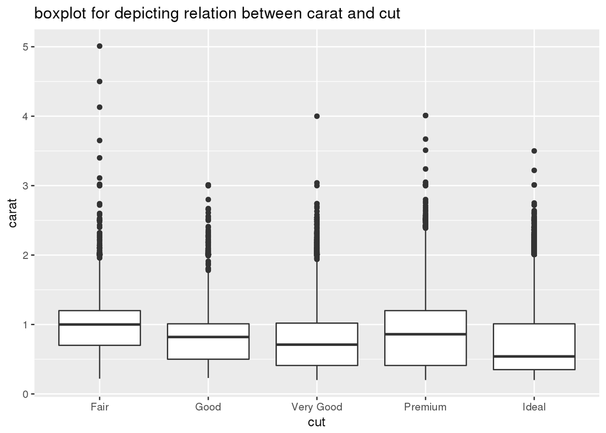

```r
ggplot(diamonds) +
  geom_boxplot(aes(x = cut, y = carat)) +
  labs(
    title = "boxplot for depicting relation between carat and cut"
  )
```

- Comparing the means of carat for cut of diamonds, we can see the fair cut diamonds have the greatest carat and the ideal cut diamonds have the least carat. From the previous discussion, we know carat is highly contributed to the price. Thus, lower quality diamonds (fair cut) have larger carat, which leads to higher price.
3. Install the ggstance package, and create a horizontal boxplot. How does this compare to using coord_flip()?

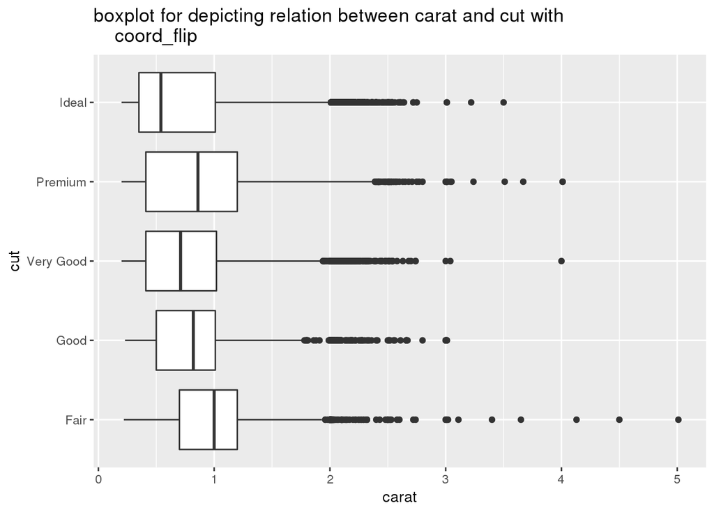

```r
# coord_flip()
ggplot(diamonds) +
  geom_boxplot(aes(x = cut, y = carat)) +
  coord_flip() +
  labs(
    title = "boxplot for depicting relation between carat and cut with
    coord_flip"
  )
```

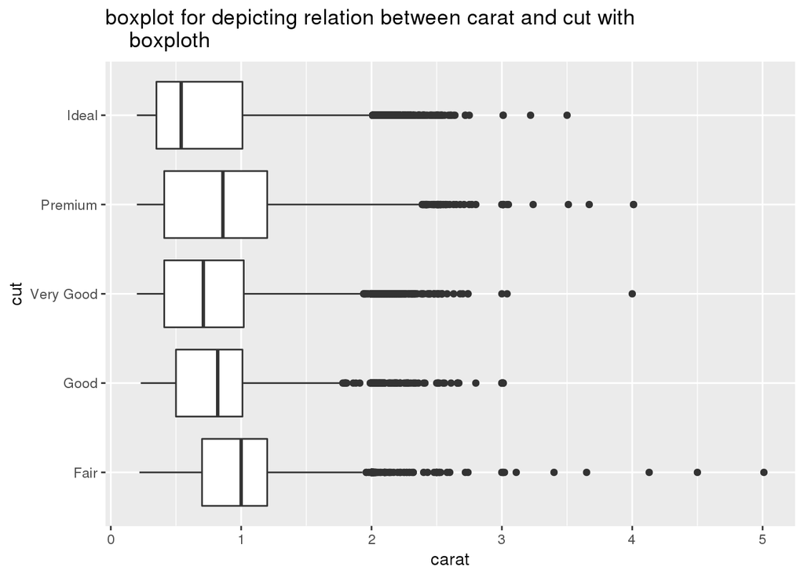

```r
# geom_boxploth()
ggplot(diamonds) +
  geom_boxploth(aes(x = carat, y = cut)) +
  labs(
    title = "boxplot for depicting relation between carat and cut with
    boxploth"
  )
```

- The two functions give the similar results. But we need to flip the coordinates when using geom_boxploth().
4. One problem with boxplots is that they were developed in an era of much smaller datasets and tend to display a prohibitively large number of “outlying values”. One approach to remedy this problem is the letter value plot. Install the lvplot package, and try using geom_lv() to display the distribution of price vs cut. What do you learn? How do you interpret the plots?

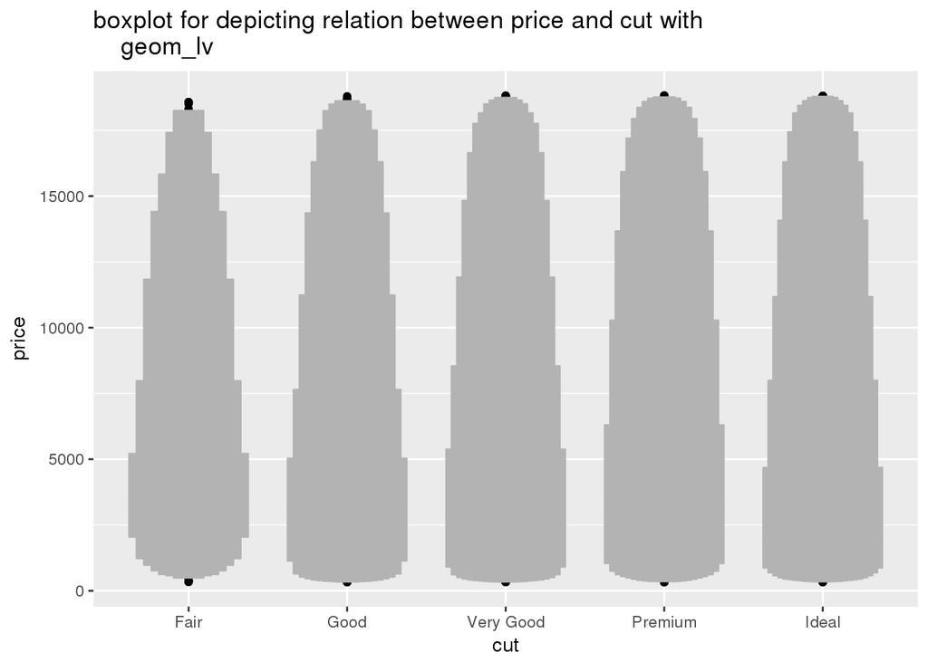

```r
ggplot(diamonds) +
  geom_lv(aes(x = cut, y = price)) +
  labs(
    title = "boxplot for depicting relation between price and cut with
    geom_lv"
  )
```

- Unlike boxplots only give the range, 1st to 3rd IQR, and outliers in the plot, the lvplot gives more information about the quantiles. In this case, boxplot cannot handle large number of data because more outliers will appear. By showing the whole quantiles directly, lvplots can deal with large data set.
- In this plot, for each category of cut, the range is slamost the same and the price is positively skewed. Comparing the plot of fair cut with others, fair cut plot has thinner tails, which indicates there are less diamonds greater than 15000$ or less than 2000$.
5. Compare and contrast geom_violin() with a facetted geom_histogram(), or a coloured geom_freqpoly(). What are the pros and cons of each method?

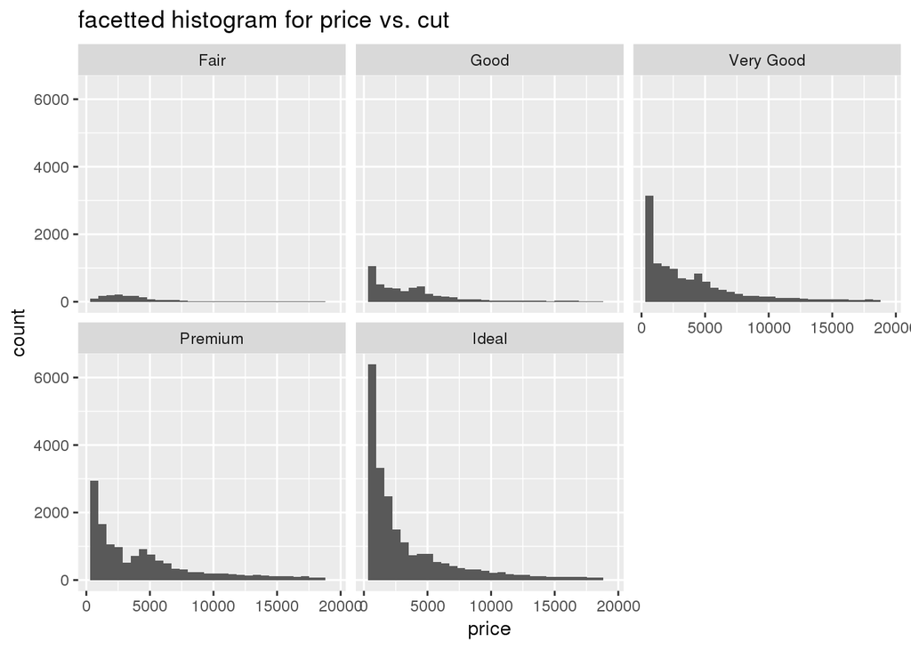

```r
# facetted histogram
ggplot(diamonds) +
  geom_histogram(aes(x = price)) +
  facet_wrap(~cut) +
  labs(
    title = "facetted histogram for price vs. cut"
  )
```

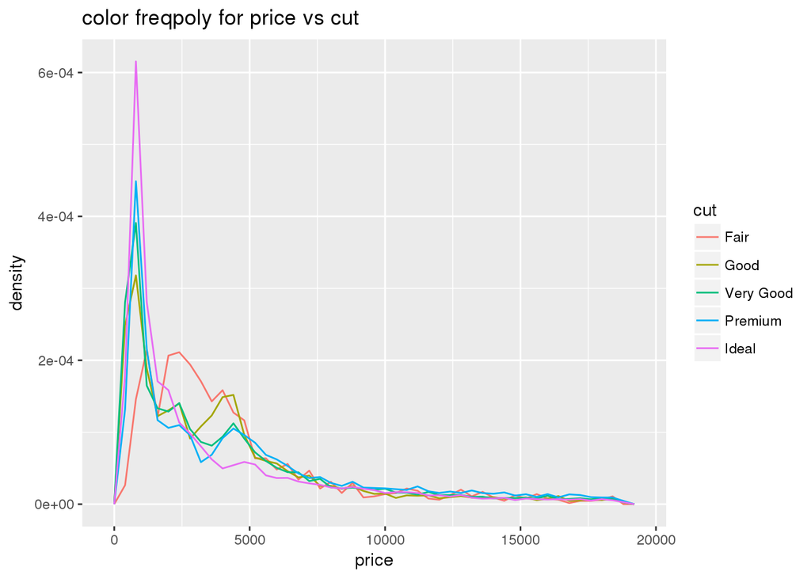

```r
# colored freqpoly
ggplot(diamonds) +
  geom_freqpoly(mapping = aes(x = price, y = ..density.., colour = cut),
                binwidth = 400) +
  labs(
    title = "color freqpoly for price vs cut"
  )
```

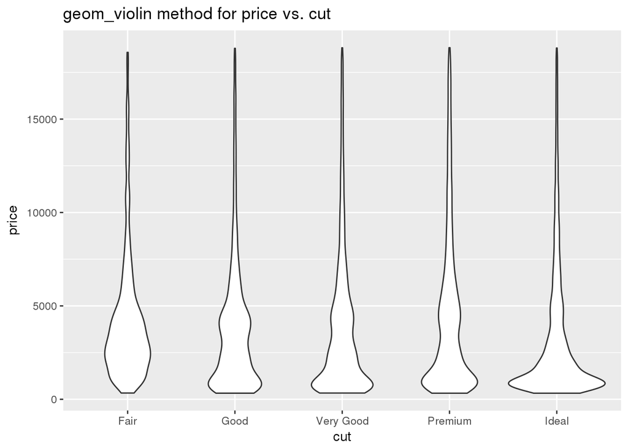

```r
##make a plot using geom_violin()
ggplot(diamonds) +
  geom_violin(aes(x = cut, y = price)) +
  labs(
    title = "geom_violin method for price vs. cut"
  )
```

- Facetted histgram gives several subplots, which is hard to compare the separate data. Colored freqpoly compares different categories by imposing them together, but is hard to distinguish when more categoreis are included. Geom_violin plot gives the clear images of the density distribution for each category, which helps to compare each group.
6. If you have a small dataset, it’s sometimes useful to use geom_jitter() to see the relationship between a continuous and categorical variable. The ggbeeswarm package provides a number of methods similar to geom_jitter(). List them and briefly describe what each one does.

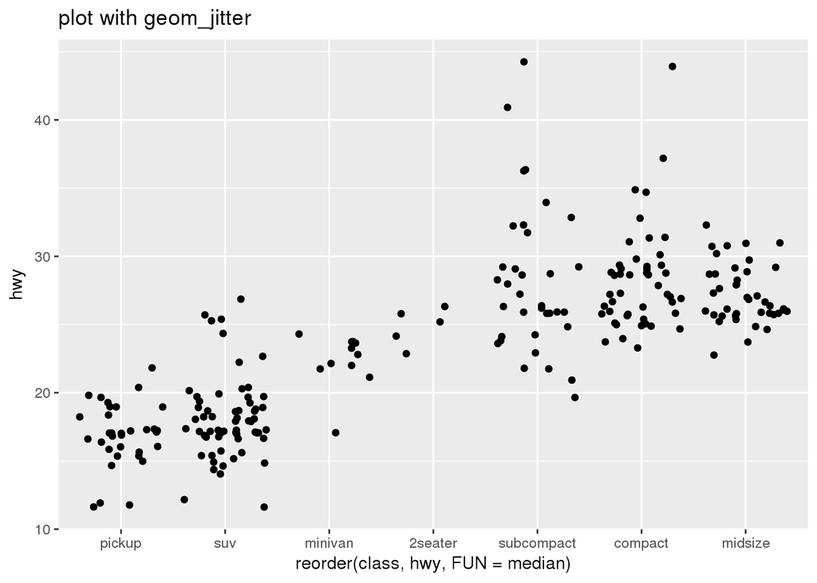

```r
# geom gitter
ggplot(mpg) +
  geom_jitter(mapping = aes(x = reorder(class, hwy, FUN = median),
                           y = hwy)) +
  labs(
    title = "plot with geom_jitter"
  )
```